# Analyzing animal movement

SOE 592 – Intro to Time Series Analysis

4 Jan 2024

# Introduction

Using time series models to analyze animal movement is common in wildlife ecology. The topic has seen increasingly more interest as the technology for tracking animals has become more sophisticated and less expensive. In this lab, we’ll see how to use multivariate state-space models to estimate movement tracks and rates of travel for several different behaviors.

# Wandering

Sometimes animals appear to be merely wandering around in search of food, mates, or resting spots. For these types of behavior, random walks models are most appropriate. For terrestrial animals, most movement models consider locations in two dimensions, latitude and longitude, and generally ignore the height above the ground. For some fishes and marine mammals, however, the models may additionally include the animal’s depth below the surface of the water. Here we will consider only two-dimensional movement, but the concepts are the same when applied to three dimensions.

## Random walk model

Recall that random walk models are extremely flexible in their ability to fit a variety of temporal patterns. As such, random walk models work really well for animals that appear to be wandering around with a lack of clear direction or a tendency to stay around some particular area.

### State model

We can write the state model for movement in two dimensions as

$$x^\text{(lat)}_t = x^\text{(lat)}_{t-1} + w^\text{(lat)}_t \\
x^\text{(lon)}_t = x^\text{(lon)}_{t-1} + w^\text{(lon)}_t \\
\Downarrow \\
\begin{bmatrix}
x^\text{(lat)} \\
x^\text{(lon)} \\
\end{bmatrix}_t =
\begin{bmatrix}
x^\text{(lat)} \\
x^\text{(lon)} \\
\end{bmatrix}_{t-1} +
\begin{bmatrix}
w^\text{(lat)} \\
w^\text{(lon)} \\
\end{bmatrix}_t \\
\Downarrow \\
\mathbf{x}_t = \mathbf{x}_{t-1} + \mathbf{w}_t \\$$

where the process errors are distributed as $\mathbf{w}_t \sim \text{MVN}(\mathbf{0}, \mathbf{Q})$.

**Tip:** The form for $\mathbf{Q}$ can be changed to account for more/less variance in the latitude or longitude step size (ie, `diagonal and unequal` in `MARSS()`), or to model covariance between the errors (ie, `equalvarcov` in `MARSS()`).

### Observation model

Our observation model is straightforward and includes terms for the data, states, and errors.

$$y^\text{(lat)}_t = x^\text{(lat)}_t + v^\text{(lat)}_t \\
y^\text{(lon)}_t = x^\text{(lon)}_t + v^\text{(lon)}_t \\
\Downarrow \\
\begin{bmatrix}
y^\text{(lat)} \\
y^\text{(lon)} \\
\end{bmatrix}_t =
\begin{bmatrix}
x^\text{(lat)} \\
x^\text{(lon)} \\
\end{bmatrix}_t +
\begin{bmatrix}
v^\text{(lat)} \\
v^\text{(lon)} \\
\end{bmatrix}_t \\
\Downarrow \\
\mathbf{y}_t = \mathbf{x}_t + \mathbf{v}_t \\$$

where the process errors are distributed as $\mathbf{v}_t \sim \text{MVN}(\mathbf{0}, \mathbf{R})$.

**Tip:** It’s rare that the variance in observation errors would be different for latitude or longitude so we typically assume that they’re “independent and identically distributed” (IID), such that the form for $\mathbf{R}$ is `diagonal and equal` in `MARSS()`.

## Simulated data

As we’ve discussed before, it’s a great idea to use simulated data when first learning to fit models, estimate parameters, and interpret their meaning. We’ll begin by simulating some data indicative of an animal that was tracked while wandering aimlessly through its habitat.

### `mvrnorm()` function

We can use the `mvrnorm()` function from the {MASS} package (note spelling here) to draw random numbers from a multivariate normal distribution, such as the process and observation errors in a MARSS model.

**Note:** If you do not already have the {MASS} package installed, do so now with `install.packages("MASS")`.

**Tip:** The `mvrnorm()` function requires 3 arguments:

1. `n`: the desired number of samples
2. `mu`: the vector specifying the means (all 0’s in our models)
3. `Sigma`: the variance-covariance matrix

## Create animal track

**Task:** Simulate some data from a two-dimensional random walk and plot the animal’s track.

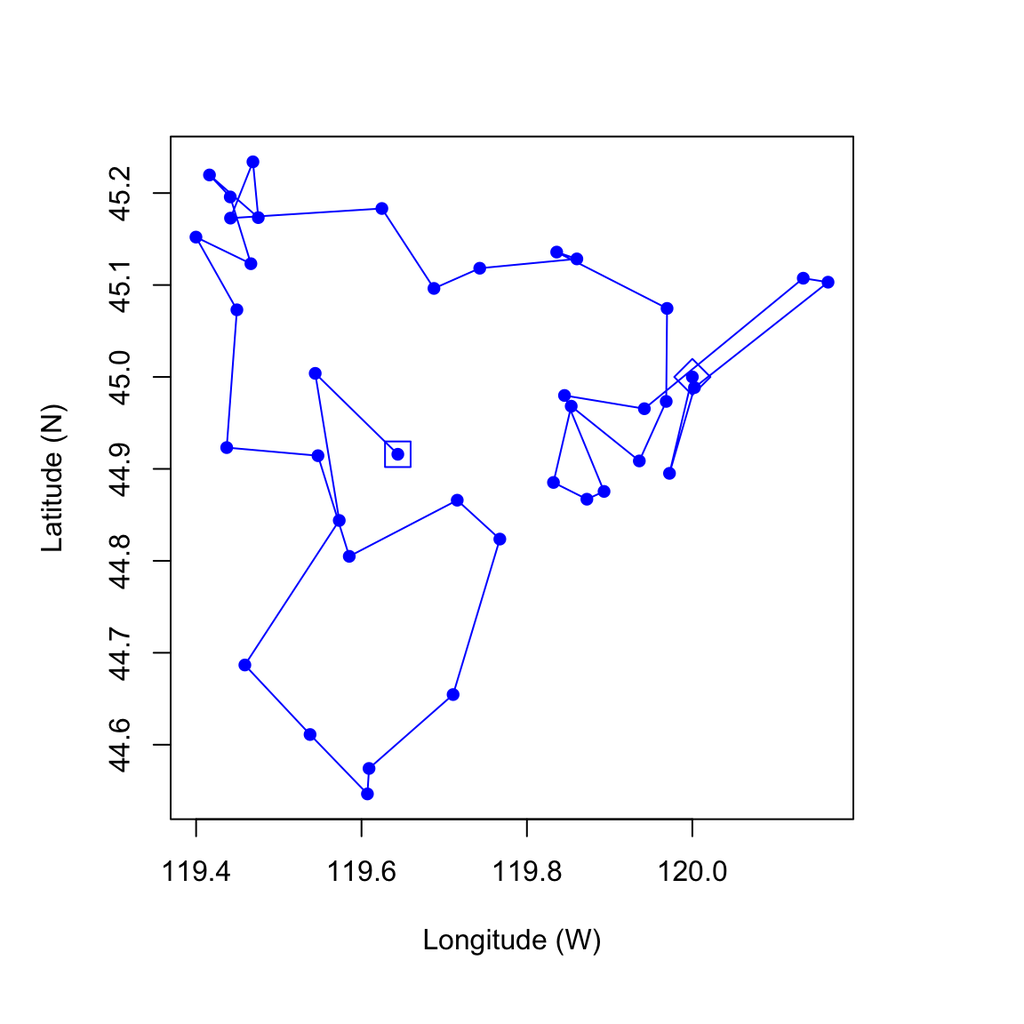

Simulated track of an animal wandering around its habitat, starting at the diamond and ending at the square.

```r
## load MASS library
library(MASS)

## number of time steps
TT <- 40

## var-cov matrix for process errors (Q); no covariance
QQ <- diag(c(0.007, 0.007))

## process errors; transposed to match equational form
ww <- mvrnorm(n = TT, mu = c(0, 0), Sigma = QQ) |> t()

## initialize state vector
xx <- ww

## set starting lat & lon (degrees N & W)
xx[,1] <- c(45, 120)

## random walk; 1st row is latitude, 2nd row is longitude
for(t in 2:TT) {
  xx[,t] <- xx[,t-1] + ww[,t]
}

## plot the true locations
par(mai = c(1.2, 1, 0.3, 0),
    omi = c(0, 0, 0.5, 1))
plot(xx[2,], xx[1, ],
     pch = 16, type = "o", col = "blue",
     xlab = "Longitude (W)", ylab = "Latitude (N)")
## add start & end points
points(xx[2, 1], xx[1, 1],
       pch = 5, cex = 2, col = "blue")
points(xx[2, TT], xx[1, TT],
       pch = 0, cex = 2, col = "blue")
```

**Task:** Add some observation error to the true locations and plot both time series.

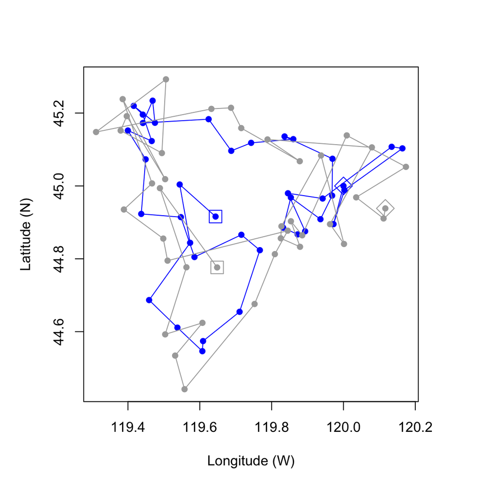

Simulated true track of an animal wandering around its habitat (blue) and the observed locations (gray). Each track starts at the diamond and ends at the square.

```r
## var-cov matrix for obs errors (R); no covariance
RR <- diag(c(0.004, 0.004))

## obs errors; transposed to match states
vv <- mvrnorm(n = TT, mu = c(0, 0), Sigma = RR) |> t()

## add errors to true locations
yy <- xx + vv

## plot the true locations
par(mai = c(1.2, 1, 0.3, 0),
    omi = c(0, 0, 0.5, 1))
plot(xx[2,], xx[1, ],
     xlim = range(xx[2, ], yy[2, ]), ylim = range(xx[1, ], yy[1, ]),
     pch = 16, type = "o", col = "blue",
     xlab = "Longitude (W)", ylab = "Latitude (N)")
## add start & end points
points(xx[2, 1], xx[1, 1],
       pch = 5, cex = 2, col = "blue")
points(xx[2, TT], xx[1, TT],
       pch = 0, cex = 2, col = "blue")
## add the obs
lines(yy[2,], yy[1,],
      type = "o", pch = 16, col = "darkgray")
points(yy[2, 1], yy[1, 1],
       pch = 5, cex = 2, col = "darkgray")
points(yy[2, TT], yy[1, TT],
       pch = 0, cex = 2, col = "darkgray")
```

## Fitting the model

Recall that when fitting models with the {MARSS} package, we need to explicitly specify the forms for *all* of the vectors and matrices in the full MARSS model given by

$$\mathbf{x}_t = \mathbf{B} \mathbf{x}_{t-1} + \mathbf{u} + \mathbf{C}
\mathbf{c}_{t-k} + \mathbf{w}_t \\
\mathbf{y}_t = \mathbf{Z} \mathbf{x}_t + \mathbf{a} + \mathbf{D}
\mathbf{d}_{t-h}+ \mathbf{v}_t \\$$

Thus, to fit our movement model for a wandering animal, we need to set the various elements of the vectors and matrices in the full form model to either 0 or 1. Specifically, we set the following:

$$\begin{align}
\mathbf{B} &=
\begin{bmatrix}
1 & 0 \\ 0 & 1
\end{bmatrix} \\
\mathbf{u} &=
\begin{bmatrix}
0 \\ 0
\end{bmatrix} \\
\mathbf{C} &=
\begin{bmatrix}
0 \\ 0
\end{bmatrix} \\
\mathbf{c}_{t-k} &=
\begin{bmatrix}
0
\end{bmatrix} \\
\mathbf{Z} &=
\begin{bmatrix}
1 & 0 \\ 0 & 1
\end{bmatrix} \\
\mathbf{a} &=
\begin{bmatrix}
0 \\ 0
\end{bmatrix} \\
\mathbf{D} &=
\begin{bmatrix}
0 \\ 0
\end{bmatrix} \\
\mathbf{d}_{t-h} &=
\begin{bmatrix}
0
\end{bmatrix}
\end{align}$$

### Matrices as lists

Because `MARSS()` uses model definitions as written in equation form, we need a way to mix both numbers and characters inside a matrix. Unfortunately, however, **R** does not let us mix `numeric` and `character` classes within a matrix. So, for example, the following code block tries to mix them in a 2x2 matrix, but everything will become a `character`.

```r
## characters along the diagonal, numbers in the off-diagonals
M <- matrix(c("a", 0, 1, "b"), 2, 2)

## this won't work
M
```

```
##      [,1] [,2]
## [1,] "a"  "1"
## [2,] "0"  "b"
```

**Tip:** We can create a matrix in R where every element is instead a `list`, which will allow us to mix `numeric` and `character` classes within a matrix.

```r
## 2x2 matrix with empty lists
M <- matrix(list(), 2, 2)

## characters along the diagonal, numbers in the off-diagonals
diag(M) <- c("a", "b")
M[1, 2] <- 1
M[2, 1] <- 0

## this works!
M
```

```
##      [,1] [,2]
## [1,] "a"  1
## [2,] 0    "b"
```

### Define the model

**Task:** Create the model list for specifying our multivariate random walk in `MARSS()`. Use a diagonal and equal $\mathbf{Q}$ and $\mathbf{R}$.

```r
## create model list for MARSS()
mod_list <- list(
  ## state model
  B = diag(2),             # 2x2 identity matrix
  U = matrix(0, 2, 1),     # 2x1 vector of biases = 0
  C = matrix(0, 2, 1),     # 2x1 vector of covariate effects = 0
  c = matrix(0),           # 1x1 matrix of covariates (none)
  Q = matrix(c(list("q"),  # 2x2 covariance matrix
               list(0),
               list(0),
               list("q")),
             2, 2),
  ## obs model
  Z = diag(2),             # 2x2 identity matrix
  A = matrix(0, 2, 1),     # 2x1 vector of offsets = 0
  D = matrix(0, 2, 1),     # 2x1 vector of covariate effects = 0
  d = matrix(0),           # 1x1 matrix of covariates (none)
  R = matrix(c(list("r"),  # 2x2 covariance matrix
               list(0),
               list(0),
               list("r")),
             2, 2)
  )
```

**Tip:** There are textual shortcuts in {MARSS} that we can use when defining the specific forms for vectors and matrices in a model list. For example, `"diagonal and equal"` gives a covariance matrix with the same elements on the diagonal and 0’s elsewhere. Type `?MARSS.marxss` or check the User Guide here for more info.

### Fit with `MARSS()`

**Task:** Fit a random walk model to our simulated data with `MARSS()`.

```r
## load {MARSS}
library(MARSS)

## fit the model
mod_rw <- MARSS(y = yy, model = mod_list)
```

```
## Success! abstol and log-log tests passed at 18 iterations.
## Alert: conv.test.slope.tol is 0.5.
## Test with smaller values (<0.1) to ensure convergence.
##
## MARSS fit is
## Estimation method: kem
## Convergence test: conv.test.slope.tol = 0.5, abstol = 0.001
## Estimation converged in 18 iterations.
## Log-likelihood: 53.33808
## AIC: -98.67616   AICc: -98.14282
##
##         Estimate
## R.r     4.65e-03
## Q.q     7.63e-03
## x0.X.Y1 4.49e+01
## x0.X.Y2 1.20e+02
## Initial states (x0) defined at t=0
##
## Standard errors have not been calculated.
## Use MARSSparamCIs to compute CIs and bias estimates.
```

### Compare the results

**Task:** Compare our estimated states with the simulate values.

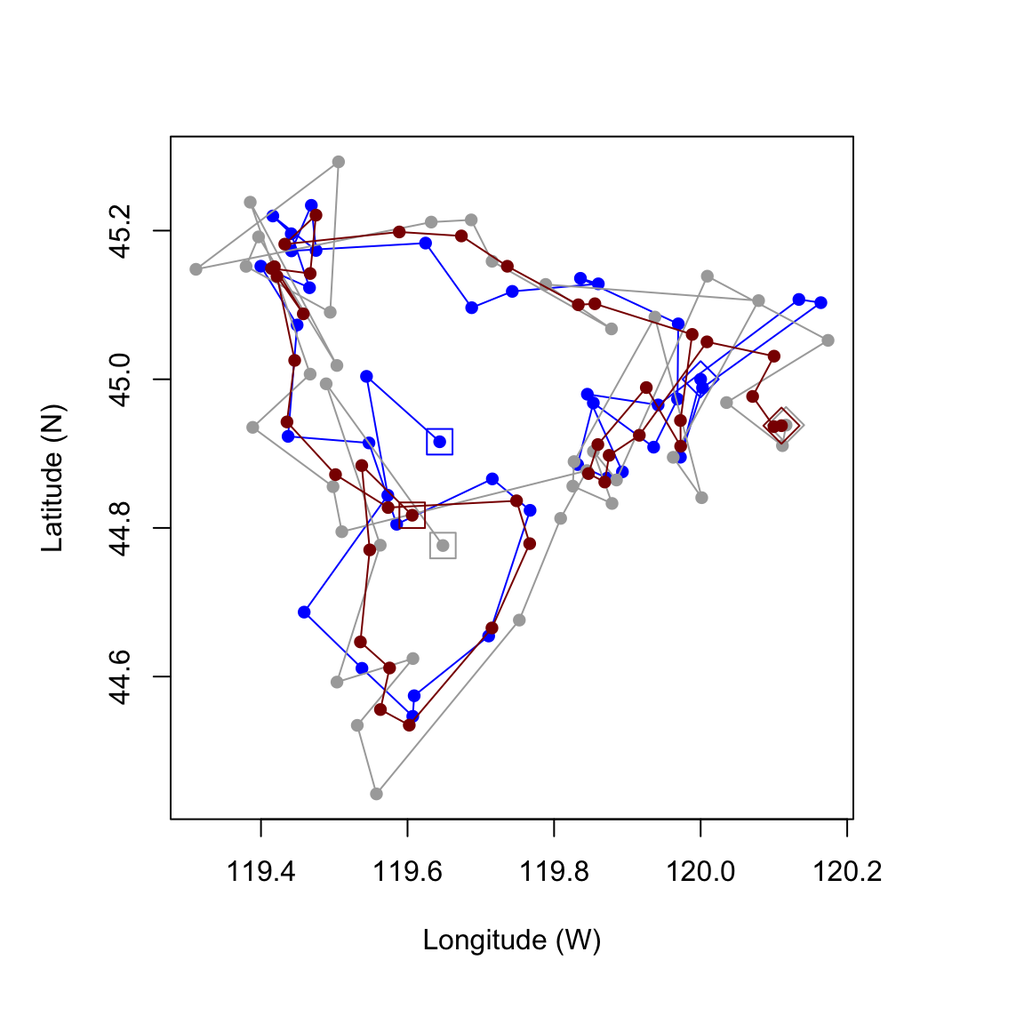

Simulated true track of an animal wandering around its habitat (blue), the observed locations (gray), and the estimated true locations (red). Each track starts at the diamond and ends at the square.

```r
## extract the estimated states
xx_hat <- mod_rw$states

## plot the estimated states with the data
par(mai = c(1.2, 1, 0.3, 0),
    omi = c(0, 0, 0.5, 1))
plot(xx[2,], xx[1, ],
     xlim = range(xx[2, ], yy[2, ], xx_hat[2, ]),
     ylim = range(xx[1, ], yy[1, ], xx_hat[1, ]),
     pch = 16, type = "o", col = "blue",
     xlab = "Longitude (W)", ylab = "Latitude (N)")
## add start & end points
points(xx[2, 1], xx[1, 1],
       pch = 5, cex = 2, col = "blue")
points(xx[2, TT], xx[1, TT],
       pch = 0, cex = 2, col = "blue")
## add the obs
lines(yy[2,], yy[1,],
      type = "o", pch = 16, col = "darkgray")
points(yy[2, 1], yy[1, 1],
       pch = 5, cex = 2, col = "darkgray")
points(yy[2, TT], yy[1, TT],
       pch = 0, cex = 2, col = "darkgray")
## add the estimated states
lines(xx_hat[2,], xx_hat[1,],
      type = "o", pch = 16, col = "darkred")
points(xx_hat[2, 1], xx_hat[1, 1],
       pch = 5, cex = 2, col = "darkred")
points(xx_hat[2, TT], xx_hat[1, TT],
       pch = 0, cex = 2, col = "darkred")
```

**Task:** What do you notice about the true track and its estimate? What does this say about the relative levels of estimated process and observation errors?

# Migration

Daily or seasonal migrations are one of the most fascinating and well studied behaviors in animal ecology. When modeling these behaviors, we typically want to estimate the rates of movement (eg, kilometers per day) in addition to the actual track the animal took during its migration.

## Biased random walk

For animals undertaking a directed migration, we need to modify our random walk model to include an additional term for the bias in movement direction.

### State model

Our state model for directional movement (migration) in two dimensions simply includes an additional term for the bias in both the *x* and *y* directions, such that

$$x^\text{(lat)}_t = x^\text{(lat)}_{t-1} + u^\text{(lat)} +
w^\text{(lat)}_t \\
x^\text{(lon)}_t = x^\text{(lon)}_{t-1} + u^\text{(lon)} +
w^\text{(lon)}_t \\
\Downarrow \\
\begin{bmatrix}
x^\text{(lat)} \\
x^\text{(lon)} \\
\end{bmatrix}_t =
\begin{bmatrix}
x^\text{(lat)} \\
x^\text{(lon)} \\
\end{bmatrix}_{t-1} +
\begin{bmatrix}
u^\text{(lat)} \\
u^\text{(lon)} \\
\end{bmatrix} +
\begin{bmatrix}
w^\text{(lat)} \\
w^\text{(lon)} \\
\end{bmatrix}_t \\
\Downarrow \\
\mathbf{x}_t = \mathbf{x}_{t-1} + \mathbf{u} + \mathbf{w}_t \\$$

where the process errors are again distributed as $\mathbf{w}_t \sim \text{MVN}(\mathbf{0}, \mathbf{Q})$.

**Tip:** It’s common that migrating animals tend to move in one direction more than another (eg, north-south versus east-west), which means we typically assume that the bias term $\mathbf{u}$ is `unconstrained` in `MARSS()`.

### Observation model

Our observation model does not change from the original one we used above, and is given by

$$y^\text{(lat)}_t = x^\text{(lat)}_t + v^\text{(lat)}_t \\
y^\text{(lon)}_t = x^\text{(lon)}_t + v^\text{(lon)}_t \\
\Downarrow \\
\begin{bmatrix}
y^\text{(lat)} \\
y^\text{(lon)} \\
\end{bmatrix}_t =
\begin{bmatrix}
x^\text{(lat)} \\
x^\text{(lon)} \\
\end{bmatrix}_t +
\begin{bmatrix}
v^\text{(lat)} \\
v^\text{(lon)} \\
\end{bmatrix}_t \\
\Downarrow \\
\mathbf{y}_t = \mathbf{x}_t + \mathbf{v}_t \\$$

where the process errors are distributed as $\mathbf{v}_t \sim \text{MVN}(\mathbf{0}, \mathbf{R})$.

## Create animal track

We’ll begin by simulating some data indicative of an animal that was tracked while migrating through its habitat.

**Task:** Simulate some data from a two-dimensional biased random walk and plot the animal’s track.

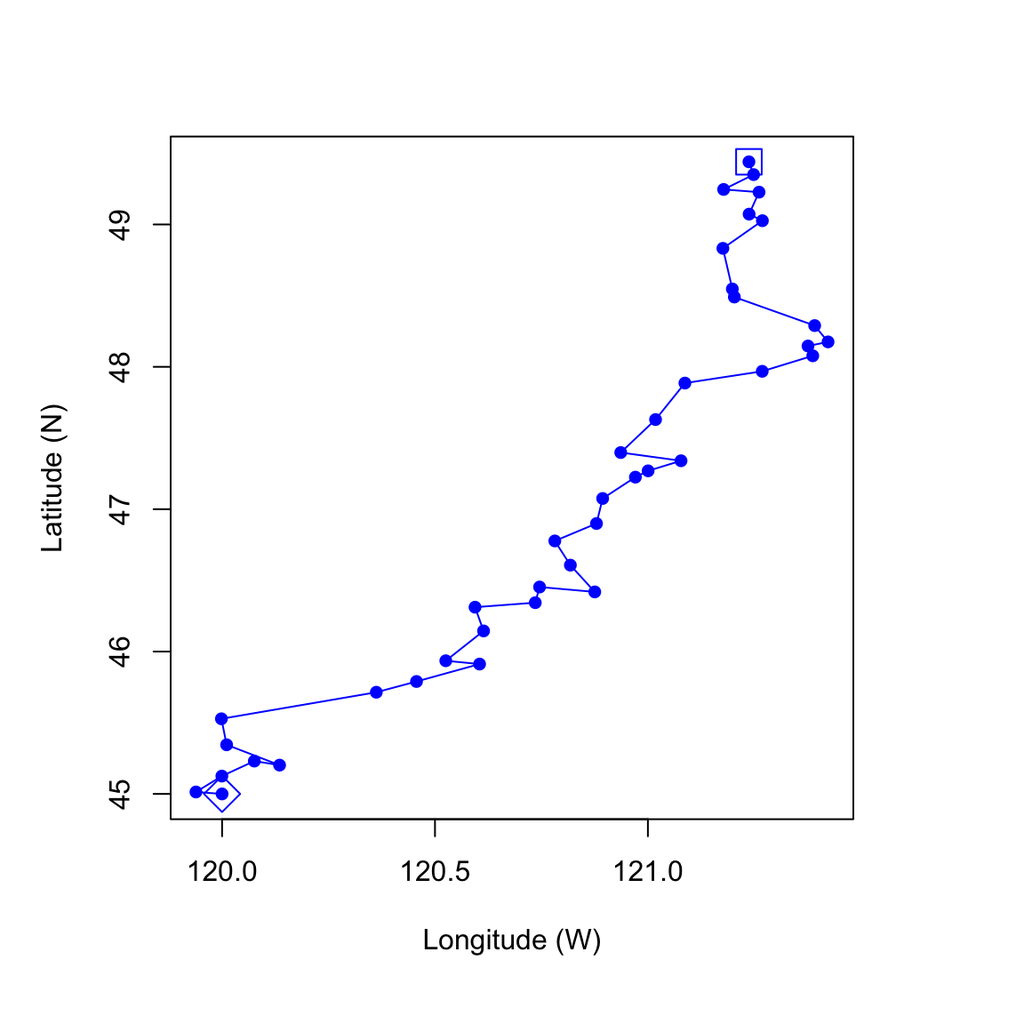

```r
## var-cov matrix for process errors (Q); no covariance
QQ <- diag(c(0.007, 0.007))

## bias terms for migration; tends north and east
uu <- matrix(c(0.1, 0.02), 2, 1)

## process errors; transposed to match equational form
ww <- mvrnorm(n = TT, mu = c(0, 0), Sigma = QQ) |> t()

## initialize state vector
xx <- ww

## set starting lat & lon (degrees N & W)
xx[,1] <- c(45, 120)

## biased random walk; 1st row is latitude, 2nd row is longitude
for(t in 2:TT) {
  xx[,t] <- xx[,t-1] + uu + ww[,t]
}

## plot the true locations
par(mai = c(1.2, 1, 0.3, 0),
    omi = c(0, 0, 0.5, 1))
plot(xx[2,], xx[1, ],
     pch = 16, type = "o", col = "blue",
     xlab = "Longitude (W)", ylab = "Latitude (N)")
## add start & end points
points(xx[2, 1], xx[1, 1],
       pch = 5, cex = 2, col = "blue")
points(xx[2, TT], xx[1, TT],
       pch = 0, cex = 2, col = "blue")
```

**Task:** Add some observation error to the true locations and plot both time series.

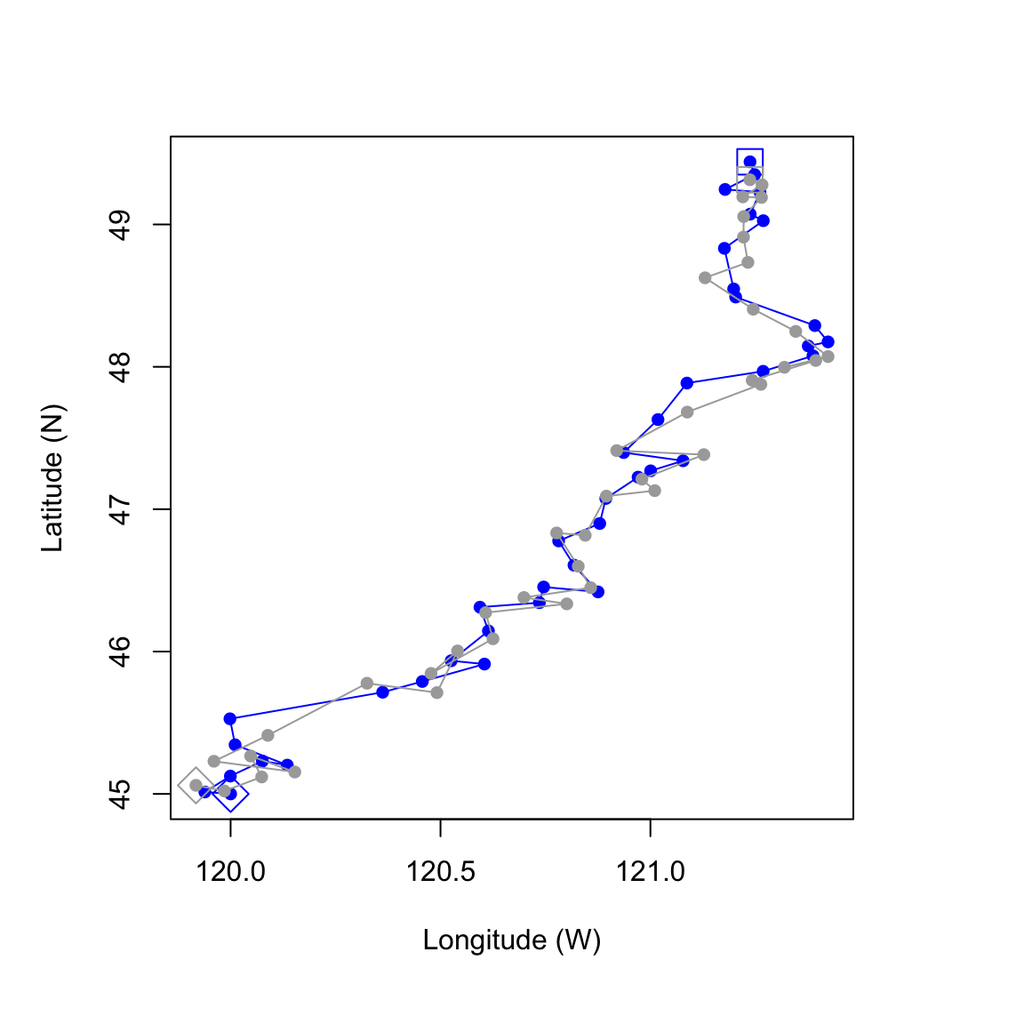

```r
## var-cov matrix for obs errors (R); no covariance
RR <- diag(c(0.004, 0.004))

## obs errors; transposed to match states
vv <- mvrnorm(n = TT, mu = c(0, 0), Sigma = RR) |> t()

## add errors to true locations
yy <- xx + vv

## plot the true locations
par(mai = c(1.2, 1, 0.3, 0),
    omi = c(0, 0, 0.5, 1))
plot(xx[2,], xx[1, ],
     xlim = range(xx[2, ], yy[2, ]), ylim = range(xx[1, ], yy[1, ]),
     pch = 16, type = "o", col = "blue",
     xlab = "Longitude (W)", ylab = "Latitude (N)")
## add start & end points
points(xx[2, 1], xx[1, 1],
       pch = 5, cex = 2, col = "blue")
points(xx[2, TT], xx[1, TT],
       pch = 0, cex = 2, col = "blue")
## add the obs
lines(yy[2,], yy[1,],
      type = "o", pch = 16, col = "darkgray")
points(yy[2, 1], yy[1, 1],
       pch = 5, cex = 2, col = "darkgray")
points(yy[2, TT], yy[1, TT],
       pch = 0, cex = 2, col = "darkgray")
```

## Fitting the model

As before with the random walk model, we need to explicitly specify the forms for *all* of the vectors and matrices in the full MARSS model given by

$$\mathbf{x}_t = \mathbf{B} \mathbf{x}_{t-1} + \mathbf{u} + \mathbf{C}
\mathbf{c}_{t-k} + \mathbf{w}_t \\
\mathbf{y}_t = \mathbf{Z} \mathbf{x}_t + \mathbf{a} + \mathbf{D}
\mathbf{d}_{t-h}+ \mathbf{v}_t \\$$

Thus, to fit our movement model for a migrating animal, we need to set the various elements of the vectors and matrices in the full form model to either 0 or 1. Specifically, we set the following:

$$\begin{align}
\mathbf{B} &=
\begin{bmatrix}
1 & 0 \\ 0 & 1
\end{bmatrix} \\
\mathbf{C} &=
\begin{bmatrix}
0 \\ 0
\end{bmatrix} \\
\mathbf{c}_{t-k} &=
\begin{bmatrix}
0
\end{bmatrix} \\
\mathbf{Z} &=
\begin{bmatrix}
1 & 0 \\ 0 & 1
\end{bmatrix} \\
\mathbf{a} &=
\begin{bmatrix}
0 \\ 0
\end{bmatrix} \\
\mathbf{D} &=
\begin{bmatrix}
0 \\ 0
\end{bmatrix} \\
\mathbf{d}_{t-h} &=
\begin{bmatrix}
0
\end{bmatrix}
\end{align}$$

### Define the model

**Task:** Create the model list for specifying our multivariate random walk in `MARSS()`. Use a diagonal and equal $\mathbf{Q}$ and $\mathbf{R}$.

**Tip:** The code block below also includes the textual shortcuts for defining a model for `MARSS()`.

```r
## create model list for MARSS()
mod_list <- list(
  ## state model
  # B = "identity",
  B = diag(2),              # 2x2 identity matrix
  # U = "unconstrained",
  U = matrix(c("NS", "EW"),  # 2x1 vector of bias terms
             2, 1),
  # C = "zero",
  C = matrix(0, 2, 1),       # 2x1 vector of covariate effects = 0
  # c = "zero",
  c = matrix(0),             # 1x1 matrix of covariates (none)
  # Q = "diagonal and equal",
  Q = matrix(c(list("q"),    # 2x2 covariance matrix
               list(0),
               list(0),
               list("q")),
             2, 2),
  ## obs model
  # Z = "identity",
  Z = diag(2),               # 2x2 identity matrix
  # A = "zero",
  A = matrix(0, 2, 1),       # 2x1 vector of offsets = 0
  # D = "zero",
  D = matrix(0, 2, 1),       # 2x1 vector of covariate effects = 0
  # d = "zero",
  d = matrix(0),             # 1x1 matrix of covariates (none)
  # R = "diagonal and equal",
  R = matrix(c(list("r"),    # 2x2 covariance matrix
               list(0),
               list(0),
               list("r")),
             2, 2)
  )
```

### Fit with `MARSS()`

**Task:** Fit a biased random walk model to our simulated data with `MARSS()`.

```r
## fit the model
mod_brw <- MARSS(y = yy, model = mod_list)
```

```
## Success! abstol and log-log tests passed at 17 iterations.
## Alert: conv.test.slope.tol is 0.5.
## Test with smaller values (<0.1) to ensure convergence.
##
## MARSS fit is
## Estimation method: kem
## Convergence test: conv.test.slope.tol = 0.5, abstol = 0.001
## Estimation converged in 17 iterations.
## Log-likelihood: 68.57833
## AIC: -125.1567   AICc: -124.006
##
##         Estimate
## R.r     3.70e-03
## U.NS    1.11e-01
## U.EW    3.40e-02
## Q.q     4.51e-03
## x0.X.Y1 4.49e+01
## x0.X.Y2 1.20e+02
## Initial states (x0) defined at t=0
##
## Standard errors have not been calculated.
## Use MARSSparamCIs to compute CIs and bias estimates.
```

### Compare the results

**Task:** Compare our estimated states with the simulate values.

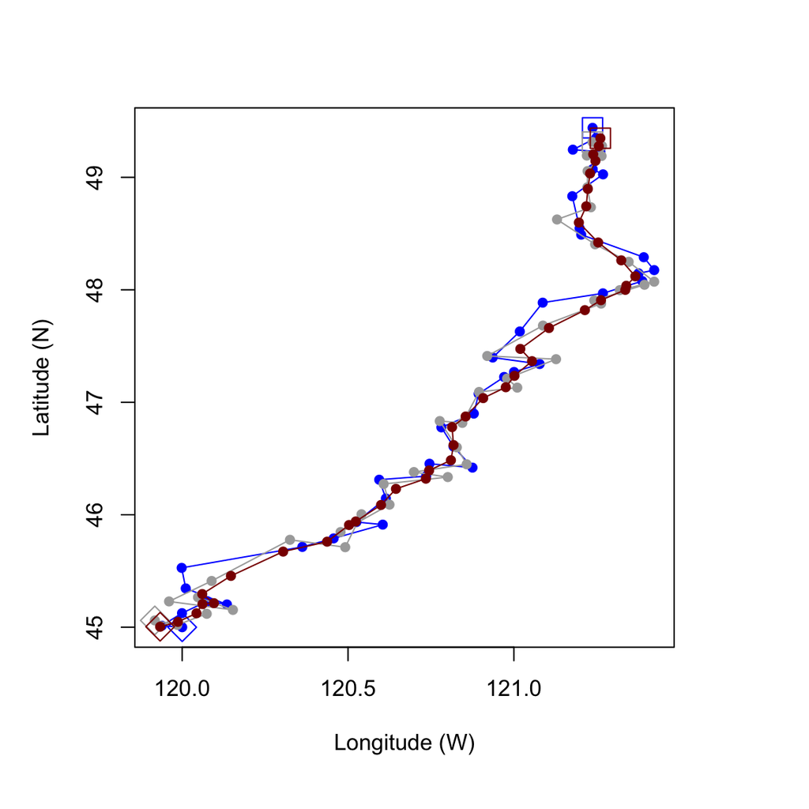

Simulated true track of an animal migrating through its habitat (blue), the observed locations (gray), and the estimated true locations (red). Each track starts at the diamond and ends at the square.

```r
## extract the estimated states
xx_hat <- mod_brw$states

## plot the estimated states with the data
par(mai = c(1.2, 1, 0.3, 0),
    omi = c(0, 0, 0.5, 1))
plot(xx[2,], xx[1, ],
     xlim = range(xx[2, ], yy[2, ], xx_hat[2, ]),
     ylim = range(xx[1, ], yy[1, ], xx_hat[1, ]),
     pch = 16, type = "o", col = "blue",
     xlab = "Longitude (W)", ylab = "Latitude (N)")
## add start & end points
points(xx[2, 1], xx[1, 1],
       pch = 5, cex = 2, col = "blue")
points(xx[2, TT], xx[1, TT],
       pch = 0, cex = 2, col = "blue")
## add the obs
lines(yy[2,], yy[1,],
      type = "o", pch = 16, col = "darkgray")
points(yy[2, 1], yy[1, 1],
       pch = 5, cex = 2, col = "darkgray")
points(yy[2, TT], yy[1, TT],
       pch = 0, cex = 2, col = "darkgray")
## add the estimated states
lines(xx_hat[2,], xx_hat[1,],
      type = "o", pch = 16, col = "darkred")
points(xx_hat[2, 1], xx_hat[1, 1],
       pch = 5, cex = 2, col = "darkred")
points(xx_hat[2, TT], xx_hat[1, TT],
       pch = 0, cex = 2, col = "darkred")
```

**Task:** What do you notice about the true track and its estimate? What does this say about the relative levels of estimated process and observation errors?

# Home range

Many animals that are not actively migrating to or from a breeding location or simply wandering around tend to establish some form of home range with which they move in search of food. For example, a female cougar with kittens in a den will forage for prey in various directions and distances from her den, but she will then return there to feed her young.

## Mean-reverting model

For animals moving within a home range, we want a model that doesn’t allow for unrestricted or directional movement and instead treats movements as temporary deviations away from some central location (ie, “mean reverting”). To do so, we will add two terms to our random walk model that account for the general stationarity in location.

### State model

Our state model for movement in two dimensions around a central location includes an additional term for the degree of mean-reversion in both the *x* and *y* directions, such that

$$x^\text{(lat)}_t = b^\text{(lat)}x^\text{(lat)}_{t-1} + w^\text{(lat)}_t
\\
x^\text{(lon)}_t = b^\text{(lon)}x^\text{(lon)}_{t-1} + w^\text{(lon)}_t
\\
\Downarrow \\
\begin{bmatrix}
x^\text{(lat)} \\
x^\text{(lon)} \\
\end{bmatrix}_t =
\begin{bmatrix}
b^\text{(lat)} & 0 \\
0 & b^\text{(lon)} \\
\end{bmatrix}_t\begin{bmatrix}
x^\text{(lat)} \\
x^\text{(lon)} \\
\end{bmatrix}_{t-1} +
\begin{bmatrix}
w^\text{(lat)} \\
w^\text{(lon)} \\
\end{bmatrix}_t \\
\Downarrow \\
\mathbf{x}_t = \mathbf{B} \mathbf{x}_{t-1} + \mathbf{w}_t \\$$

where the process errors are again distributed as $\mathbf{w}_t \sim \text{MVN}(\mathbf{0}, \mathbf{Q})$.

**Tip:** In most cases, we would expect an animal’s home range to be non-circular, which is why we’ve set the diagonal elements of $\mathbf{B}$ to be unequal. There is, however, no reason you couldn’t assume the elements were the same.

### Observation model

Our observation model does not change from the original one we’ve been using, and is given by

$$y^\text{(lat)}_t = x^\text{(lat)}_t + v^\text{(lat)}_t \\
y^\text{(lon)}_t = x^\text{(lon)}_t + v^\text{(lon)}_t \\
\Downarrow \\
\begin{bmatrix}
y^\text{(lat)} \\
y^\text{(lon)} \\
\end{bmatrix}_t =
\begin{bmatrix}
x^\text{(lat)} \\
x^\text{(lon)} \\
\end{bmatrix}_t +
\begin{bmatrix}
v^\text{(lat)} \\
v^\text{(lon)} \\
\end{bmatrix}_t \\
\Downarrow \\
\mathbf{y}_t = \mathbf{x}_t + \mathbf{v}_t \\$$

where the process errors are distributed as $\mathbf{v}_t \sim \text{MVN}(\mathbf{0}, \mathbf{R})$.

## Create animal track

**Tip:** Matrix multiplication in **R** is done with the `%*%` operator.

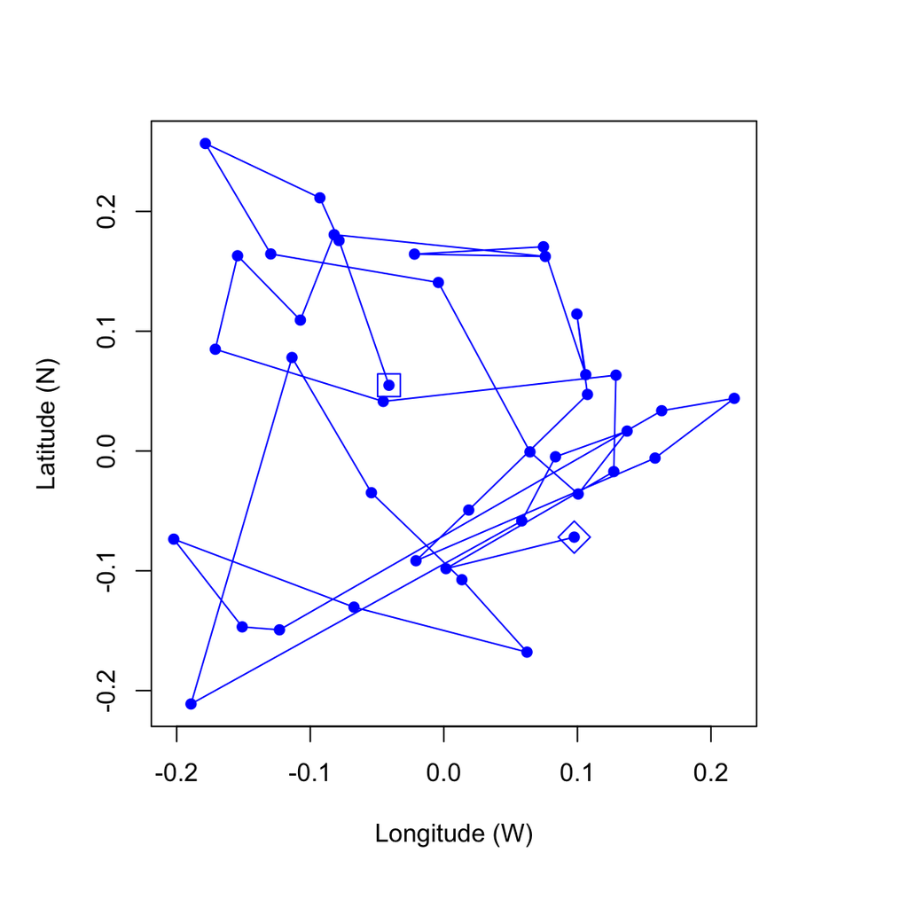

Simulated track of an animal wandering around its habitat, starting at the diamond and ending at the square.

```r
## var-cov matrix for process errors (Q); no covariance
QQ <- diag(c(0.007, 0.007))

## bias terms for mean-reversion; territory is larger from E-W than N-S
BB <- matrix(c(0.8, 0, 0, 0.5),
             2, 2)

## process errors; transposed to match equational form
ww <- mvrnorm(n = TT, mu = c(0, 0), Sigma = QQ) |> t()

## initialize state vector
xx <- ww

## set starting lat & lon (degrees N & W)
# xx[,1] <- c(45, 120)

## true states; 1st row is latitude, 2nd row is longitude
for(t in 2:TT) {
  xx[,t] <- BB %*% xx[,t-1] + ww[,t]
}

## plot the true locations
par(mai = c(1.2, 1, 0.3, 0),
    omi = c(0, 0, 0.5, 1))
plot(xx[2,], xx[1, ],
     pch = 16, type = "o", col = "blue",
     xlab = "Longitude (W)", ylab = "Latitude (N)")
## add start & end points
points(xx[2, 1], xx[1, 1],
       pch = 5, cex = 2, col = "blue")
points(xx[2, TT], xx[1, TT],
       pch = 0, cex = 2, col = "blue")
```

**Task:** Add some observation error to the true locations and plot both time series.

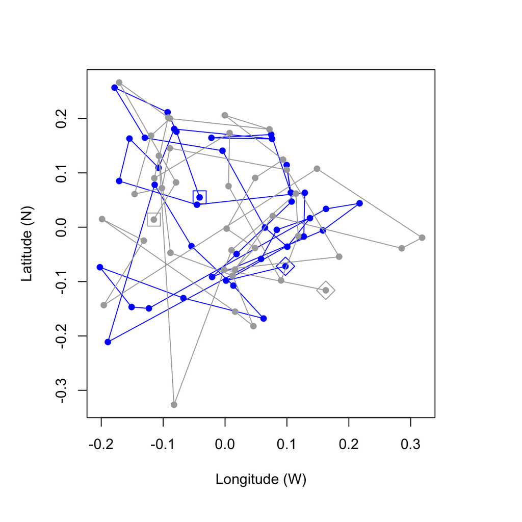

Simulated true track of an animal wandering around its habitat (blue) and the observed locations (gray). Each track starts at the diamond and ends at the square.

```r
## var-cov matrix for obs errors (R); no covariance
RR <- diag(c(0.004, 0.004))

## obs errors; transposed to match states
vv <- mvrnorm(n = TT, mu = c(0, 0), Sigma = RR) |> t()

## add errors to true locations
yy <- xx + vv

## plot the true locations
par(mai = c(1.2, 1, 0.3, 0),
    omi = c(0, 0, 0.5, 1))
plot(xx[2,], xx[1, ],
     xlim = range(xx[2, ], yy[2, ]), ylim = range(xx[1, ], yy[1, ]),
     pch = 16, type = "o", col = "blue",
     xlab = "Longitude (W)", ylab = "Latitude (N)")
## add start & end points
points(xx[2, 1], xx[1, 1],
       pch = 5, cex = 2, col = "blue")
points(xx[2, TT], xx[1, TT],
       pch = 0, cex = 2, col = "blue")
## add the obs
lines(yy[2,], yy[1,],
      type = "o", pch = 16, col = "darkgray")
points(yy[2, 1], yy[1, 1],
       pch = 5, cex = 2, col = "darkgray")
points(yy[2, TT], yy[1, TT],
       pch = 0, cex = 2, col = "darkgray")
```

## Fitting the model

As with our other models, we need to explicitly specify the forms for *all* of the vectors and matrices in the full MARSS model given by

$$\mathbf{x}_t = \mathbf{B} \mathbf{x}_{t-1} + \mathbf{u} + \mathbf{C}
\mathbf{c}_{t-k} + \mathbf{w}_t \\
\mathbf{y}_t = \mathbf{Z} \mathbf{x}_t + \mathbf{a} + \mathbf{D}
\mathbf{d}_{t-h}+ \mathbf{v}_t \\$$

To fit our movement model for a animal moving around a central location, we need to set the various elements of the vectors and matrices in the full form model to either 0 or 1. Specifically, we set the following:

$$\begin{align}
\mathbf{u} &=
\begin{bmatrix}
0 \\ 0
\end{bmatrix} \\
\mathbf{C} &=
\begin{bmatrix}
0 \\ 0
\end{bmatrix} \\
\mathbf{c}_{t-k} &=
\begin{bmatrix}
0
\end{bmatrix} \\
\mathbf{Z} &=
\begin{bmatrix}
1 & 0 \\ 0 & 1
\end{bmatrix} \\
\mathbf{a} &=
\begin{bmatrix}
0 \\ 0
\end{bmatrix} \\
\mathbf{D} &=
\begin{bmatrix}
0 \\ 0
\end{bmatrix} \\
\mathbf{d}_{t-h} &=
\begin{bmatrix}
0
\end{bmatrix}
\end{align}$$

### Define the model

**Task:** Create the model list for specifying our multivariate random walk in `MARSS()`. Use a diagonal and equal $\mathbf{Q}$ and $\mathbf{R}$.

**Tip:** The code block below uses the textual shortcuts for defining a model for `MARSS()`.

```r
## create model list for MARSS()
mod_list <- list(
  ## state model
  B = "diagonal and unequal",  # 2x2 matrix with mean-reversion on diagonal
  U = "zero",                  # 2x1 vector of bias terms
  C = "zero",                  # 2x1 vector of covariate effects = 0
  c = "zero",                  # 1x1 matrix of covariates (none)
  Q = "diagonal and equal",    # 2x2 covariance matrix
  ## obs model
  Z = "identity",              # 2x2 identity matrix
  A = "zero",                  # 2x1 vector of offsets = 0
  D = "zero",                  # 2x1 vector of covariate effects = 0
  d = "zero",                  # 1x1 matrix of covariates (none)
  R = "diagonal and equal"     # 2x2 covariance matrix
  )
```

### Fit with `MARSS()`

```r
## fit the model
mod_mar <- MARSS(y = yy, model = mod_list)
```

### Compare the results

**Task:** Compare our estimated states with the simulate values.

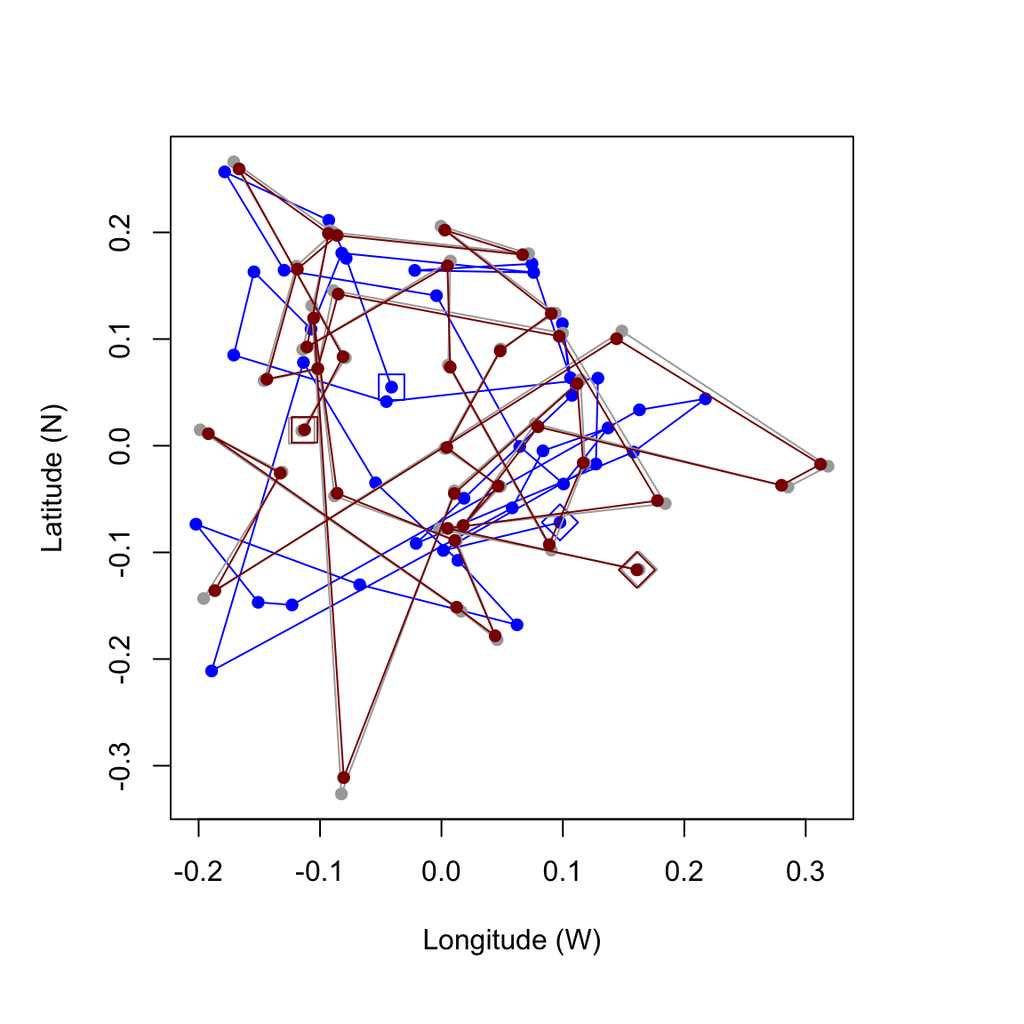

```r
## extract the estimated states
xx_hat <- mod_mar$states

## plot the estimated states with the data
par(mai = c(1.2, 1, 0.3, 0),
    omi = c(0, 0, 0.5, 1))
plot(xx[2,], xx[1, ],
     xlim = range(xx[2, ], yy[2, ], xx_hat[2, ]),
     ylim = range(xx[1, ], yy[1, ], xx_hat[1, ]),
     pch = 16, type = "o", col = "blue",
     xlab = "Longitude (W)", ylab = "Latitude (N)")
## add start & end points
points(xx[2, 1], xx[1, 1],
       pch = 5, cex = 2, col = "blue")
points(xx[2, TT], xx[1, TT],
       pch = 0, cex = 2, col = "blue")
## add the obs
lines(yy[2,], yy[1,],
      type = "o", pch = 16, col = "darkgray")
points(yy[2, 1], yy[1, 1],
       pch = 5, cex = 2, col = "darkgray")
points(yy[2, TT], yy[1, TT],
       pch = 0, cex = 2, col = "darkgray")
## add the estimated states
lines(xx_hat[2,], xx_hat[1,],
      type = "o", pch = 16, col = "darkred")
points(xx_hat[2, 1], xx_hat[1, 1],
       pch = 5, cex = 2, col = "darkred")
points(xx_hat[2, TT], xx_hat[1, TT],
       pch = 0, cex = 2, col = "darkred")
```

**Task:** What do you notice about the true track and its estimate? What does this say about the relative levels of estimated process and observation errors?

# Model comparisons

## Evidence for bias

Q: Is there data support for the bias term?

## Evidence for bias

We need to modify the model definition for `MARSS()` by setting `U = matrix(0)`

```r
mod_list <- list(
  ## state model
  B = matrix(1), U = matrix(0), Q = matrix("q"),
  ## obs model
  Z = matrix(1), A = matrix(0), R = matrix("r")
  )
```

## Re-fit the model with `MARSS()`

```r
## fit the model
# mod_fit_2 <- MARSS(y = YY, model = mod_list)
```

```r
## biased RW
# mod_fit$AICc

## unbiased RW
# mod_fit_2$AICc
```

## A note on model fitting

When we have 2+ observations of process, our estimates of model parameters are much more accurate and precise.

$$\begin{align}
x_t &= x_{t-1} + u + w_t ~~ \text{with} ~ w_t \sim \text{N}(0,q) \\
~ \\
\begin{bmatrix}
y_1 \\
y_2 \\
\vdots \\
y_n
\end{bmatrix}_t
&=
\begin{bmatrix}
1 \\
1 \\
\vdots \\
1
\end{bmatrix}
x_t +
\begin{bmatrix}
v_1 \\
v_2 \\
\vdots \\
v_n
\end{bmatrix}_t
~~ \text{with} ~
\mathbf{v_t} \sim \text{MVN}(\mathbf{0},\mathbf{R})
\end{align}$$